# Practical Machine Learning Course Project

5/1/2017

#### Preprocessing Data

```r
library(data.table)
library(dplyr)
download.file("https://d396qusza40orc.cloudfront.net/predmachlearn/pml-training.csv", destfile="pml-training.csv", method = "curl")
rawData <- fread("pml-training.csv", header=TRUE)
```

We download the data set directly and read it in as a data.table; the raw data has 19622 observations of 160 variables.

```r
rawData <- select(rawData, -V1, -user_name, -raw_timestamp_part_1,
                   -raw_timestamp_part_2, -cvtd_timestamp, -num_window,
                   -new_window)
```

The raw dataset includes the variables for the row ID, user name (i.e. the name of the person doing the weight-lifting), and timestamps; we will not be using those variables as predictors, since we want this model to be able to generalize to out-of-sample data. Without a codebook, it’s unclear what `new_window` and `num_window` represent, but we suspect they’re also specific to the trial settings.

```r
prop.missing <- apply(rawData, 2, function(x) sum(is.na(x) | x == "")/length(x))
rawData <- select(rawData, -one_of(names(prop.missing[which(prop.missing > .95)])))
```

There are 100 variables that are missing over 95% of their entries; we will remove those from the set of predictors as well. This leaves us with a more manageable set of 52 predictors. The response variable is `classe`, a categorical variable with 5 levels (A, B, C, D, E) corresponding to different ways of correctly and incorrectly performing a barbell lift. The predicto variables are measurements taken while each subject was lifting.

#### Train/Test Split

```r
library(caret)
set.seed(123)
inTrain <- createDataPartition(y=rawData$classe,p=0.7, list=FALSE)
training <- rawData[inTrain,]
testing <- rawData[-inTrain,]
```

We randomly split the data into 70% training/30% test sets.

We then fit a gradient boosted machine (GBM) to the training data, using 5-fold cross-validation to select the combination of parameters that results in the highest cross-validated accuracy:

```r
set.seed(47)
system.time(gbm.fit <- train(classe ~ ., data = training,
                 method = "gbm",
                 trControl = trainControl(method="cv", number=5),
                 verbose = FALSE))
```

```
##    user  system elapsed
## 262.140   4.648 284.684
```

```r
gbm.fit
```

```
## Stochastic Gradient Boosting
##
## 13737 samples
##    52 predictor
##     5 classes: 'A', 'B', 'C', 'D', 'E'
##
## No pre-processing
## Resampling: Cross-Validated (5 fold)
## Summary of sample sizes: 10991, 10989, 10989, 10989, 10990
## Resampling results across tuning parameters:
##
##   interaction.depth  n.trees  Accuracy   Kappa
##   1                   50      0.7531474  0.6872634
##   1                  100      0.8193921  0.7714236
##   1                  150      0.8513498  0.8119353
##   2                   50      0.8543347  0.8154469
##   2                  100      0.9044179  0.8790251
##   2                  150      0.9304063  0.9119399
##   3                   50      0.8935714  0.8652602
##   3                  100      0.9388502  0.9226239
##   3                  150      0.9592334  0.9484281
##
## Tuning parameter 'shrinkage' was held constant at a value of 0.1
##
## Tuning parameter 'n.minobsinnode' was held constant at a value of 10
## Accuracy was used to select the optimal model using  the largest value.
## The final values used for the model were n.trees = 150,
##  interaction.depth = 3, shrinkage = 0.1 and n.minobsinnode = 10.
```

Here we can visualize the change in cross-validated accuracy over the parameter combinations; the accuracy increases as the model becomes more complex (i.e. as the interaction depth and number of trees increase):

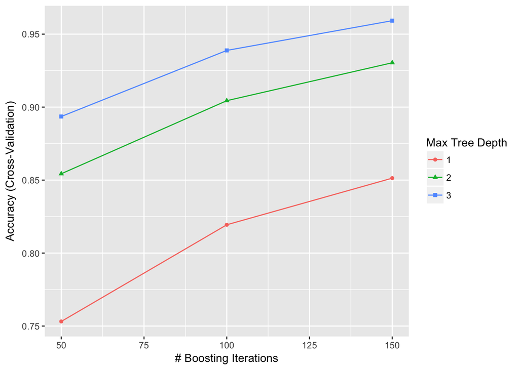

```r
ggplot(gbm.fit)
```

We can also see which variables in the dataset were the most predictive:

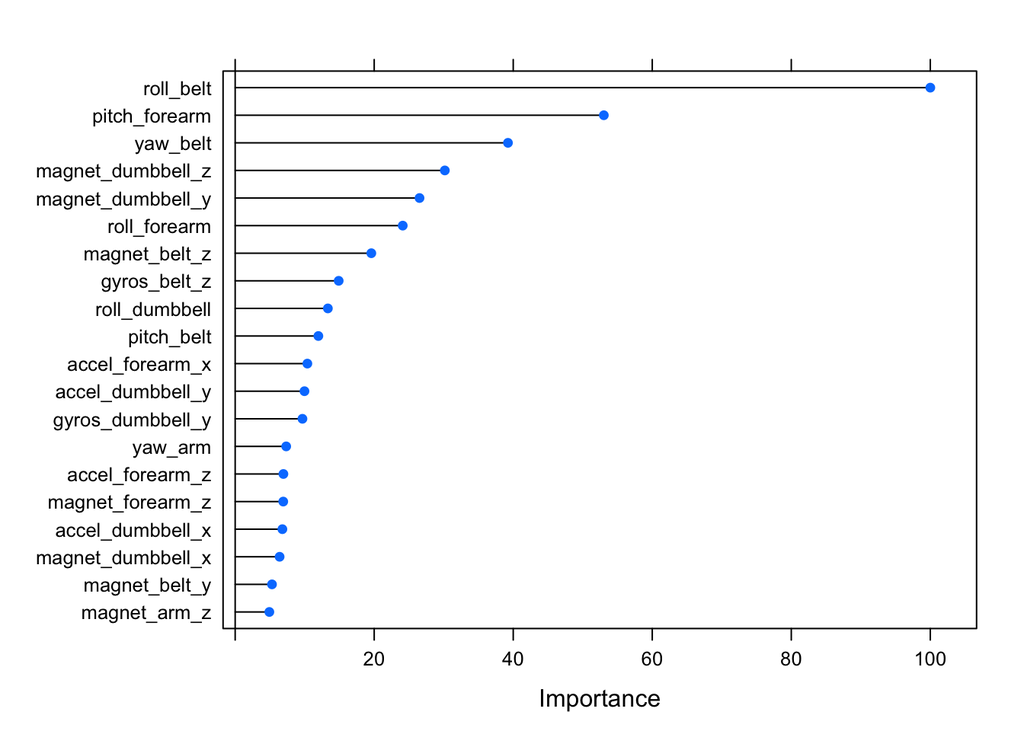

```r
plot(varImp(gbm.fit), top = 20)
```

This plot displays the `gbm` variable importance measure for the 20 most important variables to the model.

The model’s performance on the training data:

```r
confusionMatrix(predict(gbm.fit, training), training$classe)
```

```
## Confusion Matrix and Statistics
##
##           Reference
## Prediction    A    B    C    D    E
##          A 3863   75    0    3    2
##          B   26 2532   49    4   15
##          C   10   50 2318   59   16
##          D    5    1   24 2176   22
##          E    2    0    5   10 2470
##
## Overall Statistics
##
##                Accuracy : 0.9725
##                  95% CI : (0.9696, 0.9752)
##     No Information Rate : 0.2843
##     P-Value [Acc > NIR] : < 2.2e-16
##
##                   Kappa : 0.9652
##  Mcnemar's Test P-Value : 2.901e-12
##
## Statistics by Class:
##
##                      Class: A Class: B Class: C Class: D Class: E
## Sensitivity            0.9890   0.9526   0.9674   0.9663   0.9782
## Specificity            0.9919   0.9915   0.9881   0.9955   0.9985
## Pos Pred Value         0.9797   0.9642   0.9450   0.9767   0.9932
## Neg Pred Value         0.9956   0.9887   0.9931   0.9934   0.9951
## Prevalence             0.2843   0.1935   0.1744   0.1639   0.1838
## Detection Rate         0.2812   0.1843   0.1687   0.1584   0.1798
## Detection Prevalence   0.2870   0.1912   0.1786   0.1622   0.1810
## Balanced Accuracy      0.9904   0.9721   0.9778   0.9809   0.9884
```

The model’s performance on the held-out test data; we want to make sure the model isn’t overfitting to the training data before using it to make predictions on the unlabeled dataset:

```r
test.results <- confusionMatrix(predict(gbm.fit, testing), testing$classe)
test.results
```

```
## Confusion Matrix and Statistics
##
##           Reference
## Prediction    A    B    C    D    E
##          A 1649   60    0    1    6
##          B   10 1051   35    0    7
##          C   10   26  976   42    7
##          D    4    1   15  915   12
##          E    1    1    0    6 1050
##
## Overall Statistics
##
##                Accuracy : 0.9585
##                  95% CI : (0.9531, 0.9635)
##     No Information Rate : 0.2845
##     P-Value [Acc > NIR] : < 2.2e-16
##
##                   Kappa : 0.9475
##  Mcnemar's Test P-Value : 5.74e-13
##
## Statistics by Class:
##
##                      Class: A Class: B Class: C Class: D Class: E
## Sensitivity            0.9851   0.9227   0.9513   0.9492   0.9704
## Specificity            0.9841   0.9890   0.9825   0.9935   0.9983
## Pos Pred Value         0.9610   0.9529   0.9199   0.9662   0.9924
## Neg Pred Value         0.9940   0.9816   0.9896   0.9901   0.9934
## Prevalence             0.2845   0.1935   0.1743   0.1638   0.1839
## Detection Rate         0.2802   0.1786   0.1658   0.1555   0.1784
## Detection Prevalence   0.2916   0.1874   0.1803   0.1609   0.1798
## Balanced Accuracy      0.9846   0.9559   0.9669   0.9713   0.9844
```

We can use the performance on the test set to estimate the model’s out-of-sample error; the accuracy is worse than that on the training model, but a 95% CI of (0.9531281, 0.9634884) seems reasonable enough for this assignment.

```r
# To predict on the unlabeled test set
download.file("https://d396qusza40orc.cloudfront.net/predmachlearn/pml-testing.csv", destfile="pml-testing.csv", method = "curl")
test.data <- fread("pml-testing.csv", header=TRUE)
test.data <- select(test.data, -V1, -user_name, -raw_timestamp_part_1,
                   -raw_timestamp_part_2, -cvtd_timestamp, -num_window,
                   -new_window,
                   -one_of(names(prop.missing[which(prop.missing > .95)])))

test.data$pred.classe <- predict(gbm.fit, test.data)
select(test.data, problem_id, pred.classe)
```